# Environmental trajectories of 13 National Marine Sanctuaries

### Checks of the helpers on synthetic data

```r
set.seed(7)
chk <- list()

# sigma of a point 2 sd out on one of p independent variables (identity covariance)
chk$sigma <- tibble(p = c(1, 2, 6)) |>
  mutate(
    `2 SD on one variable`   = sigma_from_d2(4, p),
    `2 SD on every variable` = sigma_from_d2(4 * p, p))
stopifnot(
  abs(chk$sigma$`2 SD on one variable`[1] - 2) < 1e-9,
  abs(sigma_from_d2(4, 6) - qnorm(pchisq(4, 6) / 2 + 0.5)) < 1e-12,
  all(diff(chk$sigma$`2 SD on one variable`) < 0))

# white noise: exceedance near 5%; a 1.5 sd step in one of six variables is detected
wn <- map_dfr(1:200, \(r) {
  S  <- restd(matrix(rnorm(N_WIN * 6), ncol = 6, dimnames = list(NULL, VARS)))
  st <- dep_stats(S)
  S2 <- S; S2[!IS_BASE, 1] <- S2[!IS_BASE, 1] + 1.5
  st2 <- dep_stats(S2)
  tibble(base_cv = st$e_per["base"], post = st$e_per["post"], post_step = st2$e_per["post"],
         base_in = 100 * mean(st$sigma[IS_BASE] > 2))
})
chk$wn <- wn |> summarize(across(everything(), mean))
stopifnot(
  between(chk$wn$base_in, 3, 7),
  between(chk$wn$base_cv, 3, 12),
  between(chk$wn$post, 3, 10),
  chk$wn$post_step > 15)

# var(1) recovery on a long series
A_true <- matrix(c(0.7, 0.1, 0, 0.5), 2)
f_true <- list(A = A_true, Sig = diag(2), vars = c("a", "b"))
f_hat  <- fit_var1(sim_var1(f_true, n = 20000))
stopifnot(max(abs(f_hat$A - A_true)) < 0.03, max(abs(f_hat$Sig - diag(2))) < 0.05)

# sd floor: a month with constant values gets finite z through the floor
d_syn <- tibble(date = seq(as_date("2003-01-01"), as_date("2012-12-01"), by = "month")) |>
  mutate(nms = "X", var = "sst", value = rnorm(n()) + if_else(month(date) == 7, 0, 0))
d_syn$value[month(d_syn$date) == 7] <- 10
z_syn <- standardize(d_syn)
stopifnot(
  all(z_syn$floor_hit[month(z_syn$date) == 7]),
  all(is.finite(z_syn$z)),
  !any(z_syn$floor_hit[month(z_syn$date) != 7]))

# r2adj_fast equals vegan's adjusted r2 of the rda
Yt <- matrix(rnorm(300), 50); Xt <- matrix(rnorm(100), 50)
stopifnot(
  abs(r2adj_fast(Yt, Xt) - RsquareAdj(rda(Yt, Xt))$adj.r.squared) < 1e-10,
  abs(r2adj_fast(Yt, Xt[, 1, drop = FALSE]) - RsquareAdj(rda(Yt, Xt[, 1, drop = FALSE]))$adj.r.squared) < 1e-10)

# phase randomization keeps the amplitude spectrum; circular shift keeps the count
xs <- cumsum(rnorm(285)); xr <- phase_rand(xs)
stopifnot(
  max(abs(Mod(fft(xs - mean(xs))) - Mod(fft(xr - mean(xr))))) < 1e-6,
  sum(circ_shift(1:10 > 7, 4)) == 3)

# time-scale bands
stopifnot(
  band_of(period_of_k(3)) == "trend-like", band_of(period_of_k(4)) == "decadal",
  band_of(period_of_k(30)) == "interannual", band_of(period_of_k(31)) == "sub-annual")

chk$sigma |> mutate(across(-p, \(x) round(x, 2))) |>
  kable(caption = "Sigma dissimilarity of a point 2 SD from the centre (identity covariance): one variable vs all p")
```

Sigma dissimilarity of a point 2 SD from the centre (identity covariance): one variable vs all p

| p | 2 SD on one variable | 2 SD on every variable |
| --- | --- | --- |
| 1 | 2.00 | 2.00 |
| 2 | 1.49 | 2.36 |
| 6 | 0.42 | 3.47 |

```r
chk$wn |> mutate(across(everything(), \(x) round(x, 1))) |>
  rename(`baseline, in sample (%)` = base_in, `baseline, leave-one-year-out (%)` = base_cv,
         `2013-2025 (%)` = post, `2013-2025 with a 1.5 SD step in one variable (%)` = post_step) |>
  kable(caption = "Share of months beyond 2 sigma for white noise (p = 6, 200 series)")
```

Share of months beyond 2 sigma for white noise (p = 6, 200 series)

| baseline, leave-one-year-out (%) | 2013-2025 (%) | 2013-2025 with a 1.5 SD step in one variable (%) | baseline, in sample (%) |
| --- | --- | --- | --- |
| 6.9 | 6.7 | 18.5 | 3.9 |

## 1. Standardized anomalies

Each variable is transformed (log10 for chlorophyll and mixed-layer depth, square root for precipitation), then standardized by calendar month against 2003-2012. The SD of a calendar month is floored at half the pooled baseline SD, so near-constant months do not inflate anomalies.

```r
dz_all <- standardize(d_state |> filter(var %in% VARS))
dz     <- dz_all |> filter(date >= WIN_BEG, date <= WIN_END)

Z_list <- map(set_names(NMS_ORD), \(n) build_Z(dz, n))
stopifnot(all(map_int(Z_list, \(zi) nrow(zi$Z)) == N_WIN), all(map_int(Z_list, \(zi) ncol(zi$Z)) >= 2))
P_OF <- map_int(Z_list, \(zi) ncol(zi$Z))

dz |>
  select(nms, date, var, value, x, z) |>
  arrange(factor(nms, NMS_ORD), var, date) |>
  write_csv(out("z_monthly.csv"))
dz_all |>
  filter(var %in% c("sst", "sbt"), date >= TEMP_BEG, date <= WIN_END) |>
  select(nms, date, var, value, x, z) |>
  arrange(factor(nms, NMS_ORD), var, date) |>
  write_csv(out("z_temp_1993.csv"))

floor_tbl <- dz |>
  distinct(nms, var, mo, floor_hit) |>
  group_by(nms, var) |>
  summarize(n = sum(floor_hit, na.rm = TRUE)) |>
  pivot_wider(names_from = var, values_from = n) |>
  mutate(nms = factor(nms, NMS_ORD)) |>
  arrange(nms)
n_floor_cells  <- dz |> distinct(nms, var, mo, floor_hit) |> summarize(n = sum(floor_hit, na.rm = TRUE)) |> pull(n)
n_floor_months <- dz |> summarize(n = sum(floor_hit & !is.na(z), na.rm = TRUE)) |> pull(n)
floor_tbl |>
  kable(caption = glue(
    "Calendar months (of 12) whose SD was raised to the floor, by sanctuary and variable. ",
    "In total {n_floor_cells} sanctuary-variable-calendar-month cells, i.e. {n_floor_months} ",
    "sanctuary-variable-months in the window."))
```

Calendar months (of 12) whose SD was raised to the floor, by sanctuary and variable. In total 76 sanctuary-variable-calendar-month cells, i.e. 1745 sanctuary-variable-months in the window.

| nms | chl | mld | precip | sbt | sss | sst |
| --- | --- | --- | --- | --- | --- | --- |
| OCNMS | 0 | 6 | 0 | 0 | 0 | 0 |
| GFNMS | 0 | 2 | 3 | 1 | 0 | 0 |
| CBNMS | 0 | 2 | 3 | 0 | 0 | 0 |
| MBNMS | 0 | 2 | 3 | 1 | 0 | 1 |
| CPNMS | 0 | 2 | 3 | 1 | 0 | 0 |
| CINMS | 1 | 4 | 3 | 0 | 0 | 0 |
| PNMS | 0 | 1 | 0 | 0 | 0 | 1 |
| HIHWNMS | 0 | 0 | 4 | 0 | 0 | 1 |
| NMSAS | 0 | 1 | 0 | 0 | 0 | 0 |
| FGBNMS | 1 | 3 | 0 | 0 | 4 | 1 |
| FKNMS | 2 | 0 | 0 | 1 | 1 | 1 |
| GRNMS | 0 | 0 | 0 | 0 | 2 | 0 |
| MNMS | 0 | 0 | 2 | 0 | 3 | 4 |
| SBNMS | 0 | 5 | 0 | 0 | 0 | 0 |

```r
tibble(
  nms     = NMS_ORD,
  p       = P_OF,
  used    = map_chr(Z_list, \(zi) paste(zi$vars, collapse = ", ")),
  dropped = map_chr(Z_list, \(zi) paste(zi$dropped, collapse = ", ")),
  `missing z filled for models` = map_int(Z_list, \(zi) zi$n_na)) |>
  kable(caption = "Variables used per sanctuary")
```

Variables used per sanctuary

| nms | p | used | dropped | missing z filled for models |
| --- | --- | --- | --- | --- |
| OCNMS | 6 | sst, sbt, sss, mld, chl, precip |  | 0 |
| GFNMS | 6 | sst, sbt, sss, mld, chl, precip |  | 0 |
| CBNMS | 6 | sst, sbt, sss, mld, chl, precip |  | 0 |
| MBNMS | 6 | sst, sbt, sss, mld, chl, precip |  | 0 |
| CPNMS | 6 | sst, sbt, sss, mld, chl, precip |  | 0 |
| CINMS | 6 | sst, sbt, sss, mld, chl, precip |  | 0 |
| PNMS | 6 | sst, sbt, sss, mld, chl, precip |  | 0 |
| HIHWNMS | 6 | sst, sbt, sss, mld, chl, precip |  | 0 |
| NMSAS | 5 | sst, sss, mld, chl, precip | sbt | 0 |
| FGBNMS | 6 | sst, sbt, sss, mld, chl, precip |  | 0 |
| FKNMS | 6 | sst, sbt, sss, mld, chl, precip |  | 0 |
| GRNMS | 6 | sst, sbt, sss, mld, chl, precip |  | 0 |
| MNMS | 6 | sst, sbt, sss, mld, chl, precip |  | 0 |
| SBNMS | 6 | sst, sbt, sss, mld, chl, precip |  | 0 |

## 2. Multivariate departure from the baseline envelope

For each month, the Mahalanobis distance of the anomaly vector from the baseline centre (baseline covariance) is expressed as sigma dissimilarity, the equivalent number of SDs of a univariate normal. Baseline months are scored leave-one-year-out (`sigma_cv`).

```r
obs_stats <- map(Z_list, \(zi) dep_stats(zi$Z))
d_dep <- imap_dfr(obs_stats, \(st, n) tibble(
  nms      = n,
  date     = WIN_DATES,
  sigma    = st$sigma,
  sigma_cv = st$sigma_cv,
  exceed   = st$exceed,
  d_rms    = sqrt(rowMeans(Z_list[[n]]$Z^2, na.rm = TRUE)))) |>
  group_by(nms) |>
  mutate(
    sigma_run12  = rollmean(sigma_cv, 12, fill = NA, align = "center"),
    exceed_run12 = rollmean(as.numeric(exceed), 12, fill = NA, align = "center")) |>
  ungroup()
stopifnot(nrow(d_dep) == N_WIN * length(NMS_ORD), !anyNA(d_dep$sigma_cv))

e_base <- map_dbl(obs_stats, \(st) st$e_per["base"])
e_base_in <- map_dbl(obs_stats, \(st) 100 * mean(st$sigma[IS_BASE] > SIGMA_THR))
stopifnot(all(between(e_base, 1, 20)))
if (any(!between(e_base, 4, 13)))
  note("baseline out-of-sample exceedance outside 4-13% for {paste(NMS_ORD[!between(e_base, 4, 13)], collapse = ', ')}")
```

```
NOTE: baseline out-of-sample exceedance outside 4-13% for PNMS, FGBNMS, SBNMS
```

```r
d_dep |>
  mutate(nms = factor(nms, NMS_ORD), yr = year(date)) |>
  group_by(nms) |>
  summarize(
    `baseline in sample` = 100 * mean(sigma[yr <= 2012] > SIGMA_THR),
    `baseline out of sample` = 100 * mean(exceed[yr <= 2012]),
    `2013-2015` = 100 * mean(exceed[between(yr, 2013, 2015)]),
    `2016-2020` = 100 * mean(exceed[between(yr, 2016, 2020)]),
    `2021-2025` = 100 * mean(exceed[yr >= 2021])) |>
  mutate(across(-nms, \(x) round(x, 1))) |>
  kable(caption = glue("Share of months (%) beyond {SIGMA_THR} sigma"))
```

Share of months (%) beyond 2 sigma

| nms | baseline in sample | baseline out of sample | 2013-2015 | 2016-2020 | 2021-2025 |
| --- | --- | --- | --- | --- | --- |
| OCNMS | 5.0 | 9.2 | 44.4 | 31.7 | 24.6 |
| GFNMS | 3.3 | 5.8 | 44.4 | 36.7 | 35.1 |
| CBNMS | 1.7 | 7.5 | 47.2 | 36.7 | 29.8 |
| MBNMS | 3.3 | 7.5 | 41.7 | 48.3 | 49.1 |
| CPNMS | 1.7 | 5.8 | 44.4 | 41.7 | 31.6 |
| CINMS | 3.3 | 7.5 | 47.2 | 35.0 | 22.8 |
| PNMS | 2.5 | 15.8 | 33.3 | 40.0 | 38.6 |
| HIHWNMS | 5.8 | 10.0 | 36.1 | 63.3 | 59.6 |
| NMSAS | 0.8 | 5.0 | 19.4 | 25.0 | 35.1 |
| FGBNMS | 4.2 | 15.0 | 19.4 | 20.0 | 29.8 |
| FKNMS | 3.3 | 8.3 | 30.6 | 40.0 | 42.1 |
| GRNMS | 7.5 | 11.7 | 16.7 | 28.3 | 17.5 |
| MNMS | 5.8 | 11.7 | 19.4 | 41.7 | 33.3 |
| SBNMS | 5.0 | 14.2 | 36.1 | 43.3 | 52.6 |

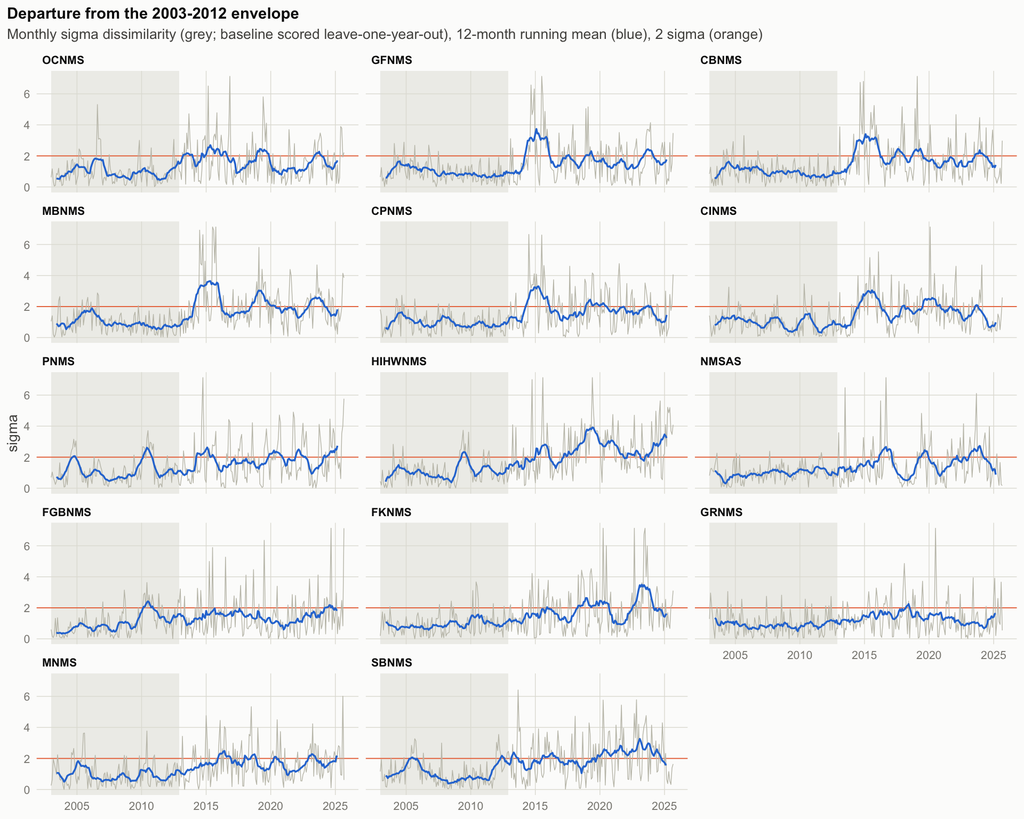

```r
p <- d_dep |>
  mutate(nms = factor(nms, NMS_ORD)) |>
  ggplot(aes(date, sigma_cv)) +
  annotate("rect", xmin = BASE_BEG, xmax = BASE_END, ymin = -Inf, ymax = Inf, fill = PAL$grid, alpha = 0.5) +
  geom_hline(yintercept = SIGMA_THR, color = PAL$orange, linewidth = 0.3) +
  geom_line(color = PAL$axis, linewidth = 0.25) +
  geom_line(aes(y = sigma_run12), color = PAL$blue, linewidth = 0.6) +
  facet_wrap(~nms, ncol = 3) +
  labs(
    title = "Departure from the 2003-2012 envelope",
    subtitle = "Monthly sigma dissimilarity (grey; baseline scored leave-one-year-out), 12-month running mean (blue), 2 sigma (orange)",
    x = NULL, y = "sigma") +
  theme_chk()
save_fig(p, "diag_sigma.png", 10, 8)
```

## 3. Null model: stationary red noise with the baseline’s own persistence

A VAR(1) fitted to each sanctuary’s baseline anomalies generates 999 stationary series of 273 months. Each is re-standardized on its first 120 months and scored exactly as the data, which gives the exceedance expected from persistence alone, without any change.

```r
var1_fits <- map(Z_list, \(zi) fit_var1(na0(zi$Z)[IS_BASE, , drop = FALSE]))
null_files <- out(c("null_draws.csv", "null_exceedance.csv", "null_var.csv"))
# recompute when an input is newer, or when the cache predates the period-mean quantiles
null_ok <- is_fresh(null_files) &&
  all(c("q025_mean", "q975_mean") %in% names(read_csv(null_files[3], n_max = 1))) &&
  setequal(unique(read_csv(null_files[2])$nms), NMS_ORD)

if (!null_ok) {
  run_null <- function(nms_i) {
    set.seed(seed_of(nms_i))
    fit  <- var1_fits[[nms_i]]
    p    <- ncol(fit$A)
    e    <- matrix(NA_real_, N_SUR, nrow(PERIODS), dimnames = list(NULL, PERIODS$period))
    vs   <- array(NA_real_, c(N_SUR, p, nrow(PERIODS_VAR)), dimnames = list(NULL, fit$vars, PERIODS_VAR$period))
    vm   <- vs
    for (r in seq_len(N_SUR)) {
      st <- dep_stats(restd(sim_var1(fit)))
      e[r, ]    <- st$e_per
      vs[r, , ] <- st$v_sh
      vm[r, , ] <- st$v_mn
    }
    list(
      draws  = as_tibble(e) |> mutate(nms = nms_i, rep = row_number()) |>
        pivot_longer(-c(nms, rep), names_to = "period", values_to = "e_pct"),
      var    = expand_grid(var = fit$vars, period = PERIODS_VAR$period) |>
        mutate(
          nms       = nms_i,
          q95_share = map2_dbl(var, period, \(v, pp) quantile(vs[, v, pp], 0.95)),
          q025_mean = map2_dbl(var, period, \(v, pp) quantile(vm[, v, pp], 0.025)),
          q975_mean = map2_dbl(var, period, \(v, pp) quantile(vm[, v, pp], 0.975))) |>
        select(nms, var, period, q95_share, q025_mean, q975_mean))
  }
  res <- mclapply(NMS_ORD, run_null, mc.cores = N_CORE)
  stopifnot(!any(map_lgl(res, \(r) inherits(r, "try-error"))))
  d_null_draws <- map_dfr(res, "draws")
  write_csv(d_null_draws, null_files[1])
  d_null_draws |>
    group_by(nms, period) |>
    summarize(q50 = quantile(e_pct, 0.5), q95 = quantile(e_pct, 0.95), q99 = quantile(e_pct, 0.99)) |>
    ungroup() |>
    write_csv(null_files[2])
  write_csv(map_dfr(res, "var"), null_files[3])
}
d_null_draws <- read_csv(null_files[1])
d_null_e     <- read_csv(null_files[2])
d_null_var   <- read_csv(null_files[3])
stopifnot(
  nrow(d_null_draws) == N_SUR * nrow(PERIODS) * length(NMS_ORD),
  all(between(d_null_e$q50[d_null_e$period == "base"], 2, 12)),
  all(between(d_null_e$q50[d_null_e$period == "post"], 1, 15)))

tibble(
  nms       = NMS_ORD,
  p         = P_OF,
  `max |eigenvalue| of A` = round(map_dbl(var1_fits, "eig_max"), 3),
  shrunk    = map_lgl(var1_fits, "shrunk")) |>
  left_join(
    d_null_e |>
      mutate(q = glue("{round(q50, 1)} / {round(q95, 1)}")) |>
      select(nms, period, q) |>
      pivot_wider(names_from = period, values_from = q),
    by = "nms") |>
  kable(caption = "VAR(1) persistence and null exceedance (%), median / 95th percentile, by period")
```

VAR(1) persistence and null exceedance (%), median / 95th percentile, by period

| nms | p | max \|eigenvalue\| of A | shrunk | 2013-2015 | 2016-2020 | 2021-2025 | base | post |
| --- | --- | --- | --- | --- | --- | --- | --- | --- |
| OCNMS | 6 | 0.764 | FALSE | 8.3 / 19.4 | 8.3 / 18.3 | 7 / 19.3 | 8.3 / 12.5 | 8.5 / 15.7 |
| GFNMS | 6 | 0.644 | FALSE | 8.3 / 19.4 | 6.7 / 16.7 | 7 / 17.5 | 8.3 / 11.7 | 7.8 / 13.7 |
| CBNMS | 6 | 0.643 | FALSE | 8.3 / 19.4 | 8.3 / 16.7 | 7 / 17.5 | 8.3 / 11.7 | 7.8 / 15 |
| MBNMS | 6 | 0.809 | FALSE | 8.3 / 19.7 | 8.3 / 20 | 8.8 / 21.1 | 8.3 / 12.5 | 8.5 / 16.3 |
| CPNMS | 6 | 0.877 | FALSE | 8.3 / 25 | 8.3 / 23.3 | 8.8 / 24.6 | 9.2 / 12.5 | 9.2 / 19.6 |
| CINMS | 6 | 0.878 | FALSE | 8.3 / 27.8 | 10 / 25 | 8.8 / 28.1 | 9.2 / 13.3 | 9.8 / 21.6 |
| PNMS | 6 | 0.932 | FALSE | 11.1 / 44.4 | 11.7 / 43.3 | 12.3 / 43.9 | 11.7 / 16.7 | 13.1 / 35.4 |
| HIHWNMS | 6 | 0.865 | FALSE | 8.3 / 25 | 8.3 / 23.3 | 8.8 / 24.6 | 9.2 / 14.2 | 9.2 / 20.3 |
| NMSAS | 5 | 0.832 | FALSE | 8.3 / 33.3 | 8.3 / 30 | 8.8 / 29.8 | 10 / 15 | 9.8 / 24.8 |
| FGBNMS | 6 | 0.844 | FALSE | 8.3 / 25 | 8.3 / 23.3 | 8.8 / 22.8 | 9.2 / 13.3 | 9.2 / 19.6 |
| FKNMS | 6 | 0.588 | FALSE | 8.3 / 16.7 | 6.7 / 16.7 | 7 / 15.8 | 8.3 / 11.7 | 7.2 / 13.7 |
| GRNMS | 6 | 0.712 | FALSE | 5.6 / 19.4 | 6.7 / 16.7 | 7 / 17.5 | 7.5 / 11.7 | 7.2 / 14.4 |
| MNMS | 6 | 0.647 | FALSE | 5.6 / 16.7 | 6.7 / 16.7 | 7 / 15.8 | 8.3 / 11.7 | 7.2 / 14.4 |
| SBNMS | 6 | 0.882 | FALSE | 8.3 / 30.6 | 8.3 / 30 | 8.8 / 28.1 | 10 / 15 | 9.2 / 23.6 |

## 4. Status, trend and form

Each period’s exceedance is compared with its own null 95th percentile. Status: outside when 2021-2025 exceeds its null; trend: change since 2016-2020 (10 points); form: the shape of the three post-baseline periods; first period outside: the first of the three whose exceedance is above its null 95th percentile.

```r
d_eper <- imap_dfr(obs_stats, \(st, n) tibble(
  nms          = n,
  period       = PERIODS$period,
  e_pct        = unname(st$e_per),
  sigma_median = map_dbl(PERIODS$period, \(p) median(st$sigma_cv[PER_MASK[[p]]], na.rm = TRUE)))) |>
  left_join(d_null_e |> select(nms, period, null_q50 = q50, null_q95 = q95), by = c("nms", "period")) |>
  rowwise() |>
  mutate(p_value = p_emp(d_null_draws$e_pct[d_null_draws$nms == nms & d_null_draws$period == period], e_pct)) |>
  ungroup()

d_eann <- imap_dfr(obs_stats, \(st, n) tibble(
  nms        = n,
  year       = YEARS,
  e_pct      = unname(st$e_ann),
  sigma_mean = map_dbl(YEARS, \(y) mean(st$sigma_cv[YR_WIN == y], na.rm = TRUE)),
  n_months   = map_int(YEARS, \(y) sum(!is.na(st$sigma_cv[YR_WIN == y])))))
d_eann |> select(nms, year, e_pct, sigma_mean, n_months) |> write_csv(out("exceedance_annual.csv"))

d_shift <- imap_dfr(Z_list, \(zi, n) expand_grid(var = zi$vars, period = c("2016-2025", "2021-2025")) |>
  mutate(
    nms      = n,
    mean_z   = map2_dbl(var, period, \(v, p) mean(zi$Z[PER_MASK[[p]], v], na.rm = TRUE)),
    share_hi = map2_dbl(var, period, \(v, p) mean(zi$Z[PER_MASK[[p]], v] > 2, na.rm = TRUE)),
    share_lo = map2_dbl(var, period, \(v, p) mean(zi$Z[PER_MASK[[p]], v] < -2, na.rm = TRUE)))) |>
  left_join(
    d_null_var |> rename(null_q95_share = q95_share, null_q025_mean = q025_mean, null_q975_mean = q975_mean),
    by = c("nms", "var", "period")) |>
  mutate(
    sig      = share_hi + share_lo > null_q95_share,
    sig_mean = mean_z < null_q025_mean | mean_z > null_q975_mean) |>
  select(nms, var, period, mean_z, share_hi, share_lo, null_q95_share, sig, null_q025_mean, null_q975_mean, sig_mean)
stopifnot(!anyNA(d_shift$null_q95_share), !anyNA(d_shift$sig_mean))
write_csv(d_shift, out("shift_by_var.csv"))

# status, trend, form, first period outside ----
classify_form <- function(E, Q) {
  x <- E > Q
  m <- max(E[1:2])
  case_when(
    !x[3] & !any(x[1:2]) ~ "within baseline range",
    !x[3]                ~ "excursion and return",
    E[3] >= m + 10       ~ "growing departure",
    E[3] <= m - 10       ~ "partial return",
    TRUE                 ~ "sustained departure")
}
d_status <- d_eper |>
  filter(period %in% c("2013-2015", "2016-2020", "2021-2025")) |>
  group_by(nms) |>
  arrange(period, .by_group = TRUE) |>
  summarize(
    status = if_else(e_pct[3] > null_q95[3], "outside", "within"),
    delta  = e_pct[3] - e_pct[2],
    trend  = case_when(delta >= 10 ~ "increasing", delta <= -10 ~ "decreasing", TRUE ~ "steady"),
    form   = classify_form(e_pct, null_q95),
    first_period_outside = if (any(e_pct > null_q95)) period[which(e_pct > null_q95)[1]] else NA_character_)
stopifnot(nrow(d_status) == length(NMS_ORD))

d_eper |>
  filter(period != "post") |>
  mutate(cell = glue("{round(e_pct)} ({round(null_q95)})")) |>
  select(nms, period, cell) |>
  pivot_wider(names_from = period, values_from = cell) |>
  left_join(d_status |> mutate(delta = round(delta)), by = "nms") |>
  mutate(nms = factor(nms, NMS_ORD)) |>
  arrange(nms) |>
  kable(caption = "Exceedance (%) by period with the null 95th percentile in brackets; status, trend and form")
```

Exceedance (%) by period with the null 95th percentile in brackets; status, trend and form

| nms | base | 2013-2015 | 2016-2020 | 2021-2025 | status | delta | trend | form | first_period_outside |
| --- | --- | --- | --- | --- | --- | --- | --- | --- | --- |
| OCNMS | 9 (12) | 44 (19) | 32 (18) | 25 (19) | outside | -7 | steady | partial return | 2013-2015 |
| GFNMS | 6 (12) | 44 (19) | 37 (17) | 35 (18) | outside | -2 | steady | sustained departure | 2013-2015 |
| CBNMS | 8 (12) | 47 (19) | 37 (17) | 30 (18) | outside | -7 | steady | partial return | 2013-2015 |
| MBNMS | 8 (12) | 42 (20) | 48 (20) | 49 (21) | outside | 1 | steady | sustained departure | 2013-2015 |
| CPNMS | 6 (12) | 44 (25) | 42 (23) | 32 (25) | outside | -10 | decreasing | partial return | 2013-2015 |
| CINMS | 8 (13) | 47 (28) | 35 (25) | 23 (28) | within | -12 | decreasing | excursion and return | 2013-2015 |
| PNMS | 16 (17) | 33 (44) | 40 (43) | 39 (44) | within | -1 | steady | within baseline range | NA |
| HIHWNMS | 10 (14) | 36 (25) | 63 (23) | 60 (25) | outside | -4 | steady | sustained departure | 2013-2015 |
| NMSAS | 5 (15) | 19 (33) | 25 (30) | 35 (30) | outside | 10 | increasing | growing departure | 2021-2025 |
| FGBNMS | 15 (13) | 19 (25) | 20 (23) | 30 (23) | outside | 10 | steady | sustained departure | 2021-2025 |
| FKNMS | 8 (12) | 31 (17) | 40 (17) | 42 (16) | outside | 2 | steady | sustained departure | 2013-2015 |
| GRNMS | 12 (12) | 17 (19) | 28 (17) | 18 (18) | within | -11 | decreasing | excursion and return | 2016-2020 |
| MNMS | 12 (12) | 19 (17) | 42 (17) | 33 (16) | outside | -8 | steady | sustained departure | 2013-2015 |
| SBNMS | 14 (15) | 36 (31) | 43 (30) | 53 (28) | outside | 9 | steady | sustained departure | 2013-2015 |

```r
d_shift |>
  filter(period == "2021-2025") |>
  mutate(cell = paste0(sprintf("%+.1f", mean_z), if_else(sig_mean, "†", ""), if_else(sig, "*", ""))) |>
  select(nms, var, cell) |>
  pivot_wider(names_from = var, values_from = cell) |>
  mutate(nms = factor(nms, NMS_ORD)) |>
  arrange(nms) |>
  select(nms, any_of(VARS)) |>
  kable(caption = "Mean z in 2021-2025 by variable († = mean outside the null 2.5-97.5 percentile range; * = share of months with |z| > 2 above the null 95th percentile)")
```

Mean z in 2021-2025 by variable († = mean outside the null 2.5-97.5 percentile range; * = share of months with |z| > 2 above the null 95th percentile)

| nms | sst | sbt | sss | mld | chl | precip |
| --- | --- | --- | --- | --- | --- | --- |
| OCNMS | +0.6† | +0.7 | +0.4 | -0.2 | -0.2 | -0.3* |
| GFNMS | +0.9†* | +1.3†* | -0.4 | -0.3 | -0.2 | -0.0 |
| CBNMS | +0.3 | +1.0†* | +0.4* | +0.1 | -0.1 | -0.0* |
| MBNMS | +1.1†* | +1.7†* | +0.3 | -0.1 | -0.7† | -0.0 |
| CPNMS | +0.8† | +1.5†* | +0.6 | -0.0 | -0.5 | -0.4† |
| CINMS | +0.6 | +0.2 | +0.4 | -1.0†* | -0.6 | -0.6† |
| PNMS | +1.6†* | +1.2 | -0.2 | +0.4 | -0.3 | -0.1 |
| HIHWNMS | +1.1† | +0.6 | -0.3 | -1.2†* | +1.4†* | -0.4 |
| NMSAS | +0.7 | NA | +0.6 | +0.6†* | +0.2 | -0.2* |
| FGBNMS | +1.2†* | +0.6 | +0.3 | -0.2 | -0.2 | +0.4† |
| FKNMS | +1.2†* | +1.4†* | +0.5†* | -0.1 | +0.3* | -0.0 |
| GRNMS | +0.1 | +0.2 | -0.1 | +0.6†* | -0.1 | +0.3 |
| MNMS | +0.9† | +1.3† | +0.5 | +0.7† | -1.2†* | -0.2* |
| SBNMS | +1.1† | +1.5† | +0.1 | +0.3 | +0.1* | +0.5†* |

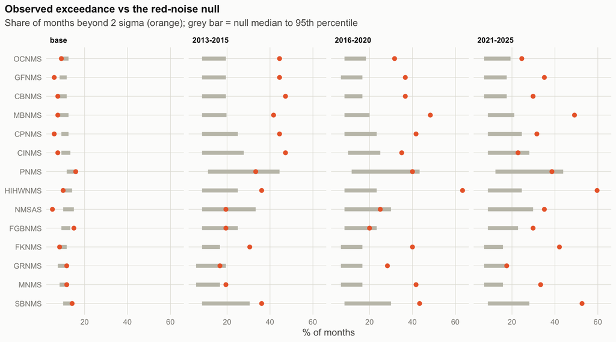

```r
p <- d_eper |>
  filter(period %in% c("base", "2013-2015", "2016-2020", "2021-2025")) |>
  mutate(nms = factor(nms, rev(NMS_ORD)), period = factor(period, c("base", "2013-2015", "2016-2020", "2021-2025"))) |>
  ggplot(aes(y = nms)) +
  geom_linerange(aes(xmin = null_q50, xmax = null_q95), color = PAL$axis, linewidth = 2) +
  geom_point(aes(x = e_pct), color = PAL$orange, size = 1.8) +
  facet_wrap(~period, nrow = 1) +
  labs(
    title = "Observed exceedance vs the red-noise null",
    subtitle = "Share of months beyond 2 sigma (orange); grey bar = null median to 95th percentile",
    x = "% of months", y = NULL) +
  theme_chk()
save_fig(p, "diag_null.png", 9, 5)
```

## 5. Temporal eigenfunction model (AEM-RDA)

One model per sanctuary on all 273 months: eigenfunctions with positive Moran’s I, forward selection with the double stopping rule, then RDA. Selected eigenfunctions are grouped by full-cycle period into four time-scale bands.

```r
E_aem <- get_aem(N_WIN)
stopifnot(nrow(E_aem) == N_WIN, ncol(E_aem) > 50)
aem_files <- out(c("aem_selected.csv"))

if (!is_fresh(aem_files)) {
  res <- mclapply(NMS_ORD, \(n) {
    set.seed(seed_of(n, 1))
    fit_aem_sel(na0(Z_list[[n]]$Z), E_aem, nperm = NPERM_AEM) |> mutate(nms = n, .before = 1)
  }, mc.cores = N_CORE)
  stopifnot(!any(map_lgl(res, \(r) inherits(r, "try-error"))))
  bind_rows(res) |>
    mutate(period_yr = period_of_k(k), band = band_of(period_yr)) |>
    select(nms, k, period_yr, band, r2adj_increment, p_value) |>
    write_csv(aem_files[1])
}
d_aem_sel <- read_csv(aem_files[1])

d_aem_bands <- expand_grid(nms = NMS_ORD, band = BANDS) |>
  left_join(d_aem_sel |> group_by(nms, band) |> summarize(r2adj = sum(r2adj_increment)), by = c("nms", "band")) |>
  mutate(r2adj = replace_na(r2adj, 0))
d_aem_tot <- tibble(nms = NMS_ORD, p = P_OF) |>
  left_join(d_aem_sel |> group_by(nms) |> summarize(r2adj = sum(r2adj_increment), n_selected = n()), by = "nms") |>
  mutate(r2adj = replace_na(r2adj, 0), n_selected = replace_na(n_selected, 0L)) |>
  select(nms, r2adj, n_selected, p)
write_csv(d_aem_bands, out("aem_bands.csv"))
write_csv(d_aem_tot, out("aem_total.csv"))

# fitted states; the rda adjusted r2 must equal the summed increments
d_fit <- map_dfr(NMS_ORD, \(n) {
  Y  <- na0(Z_list[[n]]$Z)
  ks <- d_aem_sel$k[d_aem_sel$nms == n]
  if (length(ks) > 0) {
    r2 <- RsquareAdj(get_rda(Y, E_aem, ks))$adj.r.squared
    stopifnot(abs(r2 - sum(d_aem_sel$r2adj_increment[d_aem_sel$nms == n])) < 1e-6)
    Fz <- fit_states(Y, E_aem, ks)
  } else {
    Fz <- matrix(colMeans(Y), N_WIN, ncol(Y), byrow = TRUE, dimnames = list(NULL, colnames(Y)))
  }
  as_tibble(Fz) |> mutate(nms = n, date = WIN_DATES) |>
    pivot_longer(-c(nms, date), names_to = "var", values_to = "z_fit")
}) |> select(nms, date, var, z_fit)
write_csv(d_fit, out("fitted_monthly.csv"))

d_aem_bands |>
  mutate(r2adj = round(100 * r2adj, 1), band = factor(band, BANDS)) |>
  pivot_wider(names_from = band, values_from = r2adj, names_sort = TRUE) |>
  left_join(d_aem_tot |> mutate(`total (%)` = round(100 * r2adj, 1)) |> select(nms, `total (%)`, `selected` = n_selected), by = "nms") |>
  mutate(nms = factor(nms, NMS_ORD)) |>
  arrange(nms) |>
  kable(caption = "Adjusted R2 (%) of the eigenfunction model by time-scale band (full-cycle period: sub-annual <= 1.5 yr, interannual 1.5-8, decadal 8-15, trend-like > 15)")
```

Adjusted R2 (%) of the eigenfunction model by time-scale band (full-cycle period: sub-annual <= 1.5 yr, interannual 1.5-8, decadal 8-15, trend-like > 15)

| nms | sub-annual | interannual | decadal | trend-like | total (%) | selected |
| --- | --- | --- | --- | --- | --- | --- |
| OCNMS | 21.4 | 11.9 | 2.4 | 7.5 | 43.2 | 51 |
| GFNMS | 17.9 | 13.7 | 4.1 | 11.1 | 46.8 | 48 |
| CBNMS | 16.0 | 14.2 | 4.4 | 8.3 | 42.9 | 50 |
| MBNMS | 17.5 | 17.1 | 3.8 | 14.3 | 52.8 | 52 |
| CPNMS | 13.7 | 19.1 | 3.7 | 14.1 | 50.6 | 50 |
| CINMS | 11.6 | 23.6 | 5.2 | 14.0 | 54.4 | 49 |
| PNMS | 22.1 | 17.2 | 3.6 | 16.7 | 59.7 | 47 |
| HIHWNMS | 17.1 | 12.8 | 3.5 | 24.5 | 57.9 | 50 |
| NMSAS | 12.3 | 20.0 | 4.6 | 5.5 | 42.4 | 43 |
| FGBNMS | 16.1 | 15.0 | 3.8 | 5.6 | 40.4 | 44 |
| FKNMS | 16.7 | 10.4 | 0.7 | 9.0 | 36.7 | 41 |
| GRNMS | 18.4 | 6.1 | 0.5 | 5.2 | 30.2 | 33 |
| MNMS | 13.6 | 8.4 | 1.2 | 14.2 | 37.4 | 34 |
| SBNMS | 18.3 | 20.6 | 1.2 | 12.3 | 52.4 | 54 |

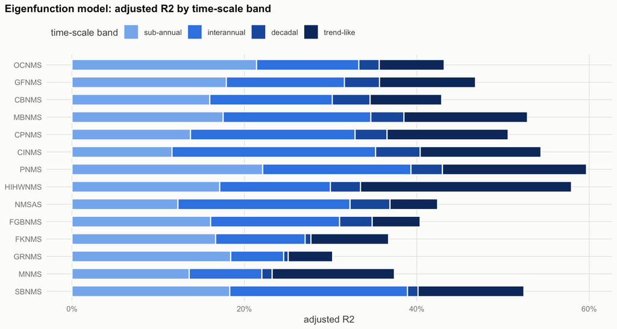

```r
p <- d_aem_bands |>
  mutate(nms = factor(nms, rev(NMS_ORD)), band = factor(band, BANDS)) |>
  ggplot(aes(r2adj, nms)) +
  geom_col(aes(fill = band), width = 0.62, color = PAL$surface, linewidth = 0.6, position = position_stack(reverse = TRUE)) +
  scale_fill_manual(values = setNames(PAL_BAND, BANDS), name = "time-scale band") +
  scale_x_continuous(labels = label_percent()) +
  labs(title = "Eigenfunction model: adjusted R2 by time-scale band", x = "adjusted R2", y = NULL) +
  theme_chk()
save_fig(p, "diag_aem_bands.png", 9, 4.8)
```

## 6. A common state space for all sanctuaries

One uncentred, unscaled PCA of the annual mean anomalies of all sanctuaries pooled: the origin is “at baseline” and units are baseline SDs. Axis 1 is oriented so `sst` loads positive, axis 2 so `chl` loads positive.

```r
ann_z <- dz |>
  mutate(year = year(date)) |>
  filter(var %in% VARS) |>
  semi_join(imap_dfr(Z_list, \(zi, n) tibble(nms = n, var = zi$vars)), by = c("nms", "var")) |>
  group_by(nms, year, var) |>
  summarize(z = mean(z, na.rm = TRUE)) |>
  ungroup() |>
  pivot_wider(names_from = var, values_from = z) |>
  right_join(expand_grid(nms = NMS_ORD, year = YEARS), by = c("nms", "year"))
for (v in setdiff(VARS, names(ann_z))) ann_z[[v]] <- 0
ann_z <- ann_z |> mutate(across(all_of(VARS), \(x) replace_na(x, 0))) |> arrange(factor(nms, NMS_ORD), year)
X_ann <- as.matrix(ann_z[, VARS])

pc  <- prcomp(X_ann, center = FALSE, scale. = FALSE)
rot <- pc$rotation[, 1:3]
if (rot["sst", 1] < 0) rot[, 1] <- -rot[, 1]
if (rot["chl", 2] < 0) rot[, 2] <- -rot[, 2]
var_share <- pc$sdev^2 / sum(pc$sdev^2)
colnames(rot) <- c("pc1", "pc2", "pc3")

d_load <- bind_rows(
  as_tibble(rot, rownames = "var"),
  tibble(var = "variance_share", pc1 = var_share[1], pc2 = var_share[2], pc3 = var_share[3]))
write_csv(d_load, out("pca_loadings.csv"))

S_ann <- X_ann %*% rot
d_pca_ann <- ann_z |> select(nms, year) |> bind_cols(as_tibble(S_ann))
write_csv(d_pca_ann, out("pca_scores_annual.csv"))

d_pca_fit <- d_fit |>
  pivot_wider(names_from = var, values_from = z_fit)
for (v in setdiff(VARS, names(d_pca_fit))) d_pca_fit[[v]] <- 0
d_pca_fit <- d_pca_fit |> mutate(across(all_of(VARS), \(x) replace_na(x, 0)))
S_fit <- as.matrix(d_pca_fit[, VARS]) %*% rot[, 1:2]
d_pca_fit <- d_pca_fit |> select(nms, date) |> bind_cols(as_tibble(S_fit))
write_csv(d_pca_fit, out("pca_scores_fit.csv"))

# 95% prediction ellipse of the ten baseline annual means ----
ellipse_of <- function(S, n_pts = 100) {
  n  <- nrow(S)
  r2 <- 2 * (n - 1) * (n + 1) / (n * (n - 2)) * qf(0.95, 2, n - 2)
  L  <- t(chol(cov(S)))
  th <- seq(0, 2 * pi, length.out = n_pts + 1)
  t(colMeans(S) + sqrt(r2) * L %*% rbind(cos(th), sin(th)))
}
d_ell <- d_pca_ann |>
  filter(year <= 2012) |>
  group_by(nms) |>
  group_modify(\(d, k) { e <- ellipse_of(as.matrix(d[, c("pc1", "pc2")])); tibble(pc1 = e[, 1], pc2 = e[, 2]) }) |>
  ungroup() |>
  arrange(factor(nms, NMS_ORD))
write_csv(d_ell, out("pca_baseline_ellipse.csv"))

d_load |> mutate(across(-var, \(x) round(x, 2))) |>
  kable(caption = "Loadings of the common state space (last row: share of the total sum of squares)")
```

Loadings of the common state space (last row: share of the total sum of squares)

| var | pc1 | pc2 | pc3 |
| --- | --- | --- | --- |
| sst | 0.67 | 0.25 | -0.17 |
| sbt | 0.70 | 0.04 | -0.03 |
| sss | 0.13 | -0.83 | -0.42 |
| mld | 0.06 | -0.35 | 0.31 |
| chl | -0.22 | 0.30 | -0.79 |
| precip | 0.00 | 0.15 | 0.27 |
| variance_share | 0.55 | 0.21 | 0.10 |

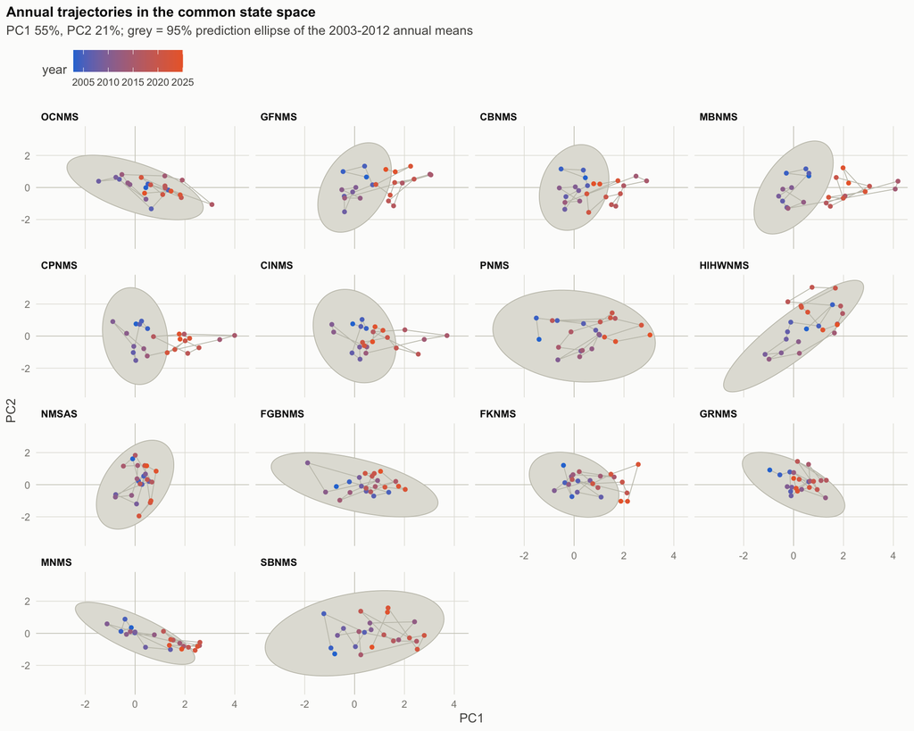

```r
p <- d_pca_ann |>
  mutate(nms = factor(nms, NMS_ORD), post = year >= 2013) |>
  ggplot(aes(pc1, pc2)) +
  geom_hline(yintercept = 0, color = PAL$axis, linewidth = 0.2) +
  geom_vline(xintercept = 0, color = PAL$axis, linewidth = 0.2) +
  geom_polygon(data = d_ell |> mutate(nms = factor(nms, NMS_ORD)), fill = PAL$grid, color = PAL$axis, linewidth = 0.3) +
  geom_path(color = PAL$axis, linewidth = 0.3) +
  geom_point(aes(color = year), size = 1.2) +
  facet_wrap(~nms, ncol = 4) +
  scale_color_gradient(low = PAL$blue, high = PAL$orange) +
  labs(
    title = "Annual trajectories in the common state space",
    subtitle = glue("PC1 {percent(var_share[1], 1)}, PC2 {percent(var_share[2], 1)}; grey = 95% prediction ellipse of the 2003-2012 annual means"),
    x = "PC1", y = "PC2") +
  theme_chk()
save_fig(p, "diag_pca.png", 10, 8)
```